# Reproducible Research: Peer Assessment 1

# **Assignment**

This assignment will be described in multiple parts. You will need to write a report that answers the questions detailed below. Ultimately, you will need to complete the entire assignment in a single R markdown document that can be processed by knitr and be transformed into an HTML file.

Throughout your report make sure you always include the code that you used to generate the output you present. When writing code chunks in the R markdown document, always use echo = TRUE so that someone else will be able to read the code. This assignment will be evaluated via peer assessment so it is essential that your peer evaluators be able to review the code for your analysis.

For the plotting aspects of this assignment, feel free to use any plotting system in R (i.e., base, lattice, ggplot2)

# **Setting up R Enviornment**

```r
setwd("C:/Users/User/Desktop/Coursera/Reproducible Research/RepData_PeerAssessment1")
library(knitr)
opts_chunk$set(echo = TRUE, results = 'hold')
library(data.table)
```

```r
library(ggplot2)
```

# **Loading and preprocessing the data**

```r
#URL <- "https://d396qusza40orc.cloudfront.net/repdata%2Fdata%2Factivity.zip"
#download.file(URL, destfile = "/data/activity.zip")
unzip("data/activity.zip")
data <- read.csv("data/activity.csv", header = TRUE, sep = ",", colClasses = c("integer", "Date", "factor"))
data$month <- as.numeric(format(data$date, "%m"))
head(data)
dim(data)
```

```
##   steps       date interval month
## 1    NA 2012-10-01        0    10
## 2    NA 2012-10-01        5    10
## 3    NA 2012-10-01       10    10
## 4    NA 2012-10-01       15    10
## 5    NA 2012-10-01       20    10
## 6    NA 2012-10-01       25    10
## [1] 17568     4
```

# **What is mean total number of steps taken per day?**

**Calculate the total number of steps taken per day**

```r
steps_day <- aggregate(steps ~ date, data, sum)
colnames(steps_day) <- c("Day","Steps")
```

**Make a histogram of the total number of steps taken each day**

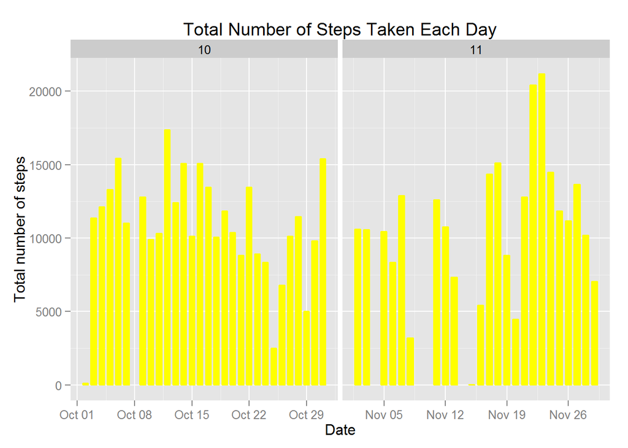

```r
ggplot(data, aes(date, steps)) + geom_bar(stat = "identity", colour = "yellow", fill = "yellow", width = 0.7) + facet_grid(. ~ month, scales = "free") + labs(title = "Total Number of Steps Taken Each Day", x = "Date", y = "Total number of steps")
```

```r
steps_mean   <- mean(steps_day$Steps, na.rm=TRUE)
steps_median <- median(steps_day$Steps, na.rm=TRUE)
```

# **What is the average daily activity pattern?**

**Make a time series plot (i.e. type = “l”) of the 5-minute interval (x-axis) and the average number of steps taken, averaged across all days (y-axis)**

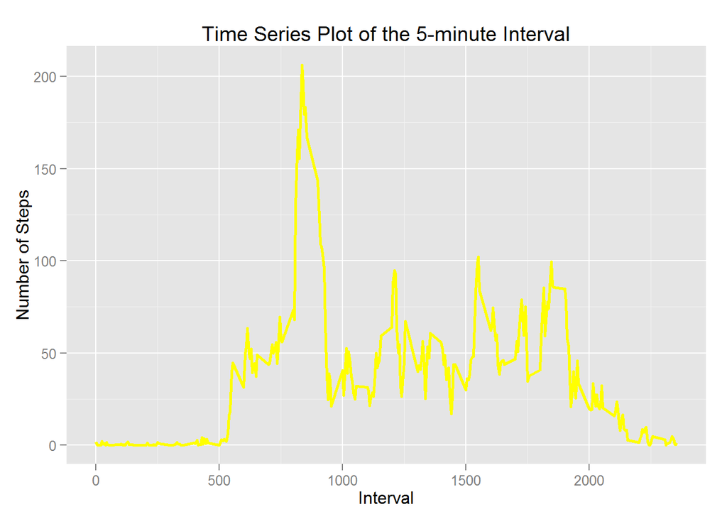

```r
steps_interval <- aggregate(data$steps, by = list(interval = as.numeric(as.character(data$interval))), FUN=mean, na.rm=TRUE)
names(steps_interval)[2] <- "StepsMean"

ggplot(steps_interval, aes(interval, StepsMean)) + geom_line(color = "yellow", size = 1) + labs(title = "Time Series Plot of the 5-minute Interval", x = "Interval", y = "Number of Steps")
```

# **Imputing missing values**

**Calculate and report the total number of missing values in the dataset (i.e. the total number of rows with NAs)**

```r
missing_data <- sum(is.na(data$steps))
```

There are 2304 missing values

**Devise a strategy for filling in all of the missing values in the dataset. The strategy does not need to be sophisticated. For example, you could use the mean/median for that day, or the mean for that 5-minute interval, etc.**

```r
updated_Data <- data
for (i in 1:nrow(updated_Data)) {
    if (is.na(updated_Data$steps[i])) {
        updated_Data$steps[i] <- steps_interval[which(updated_Data$interval[i] == steps_interval$interval), ]$StepsMean
    }
}


updated_missing_data <- sum(is.na(updated_Data))
```

There are 0 missing values

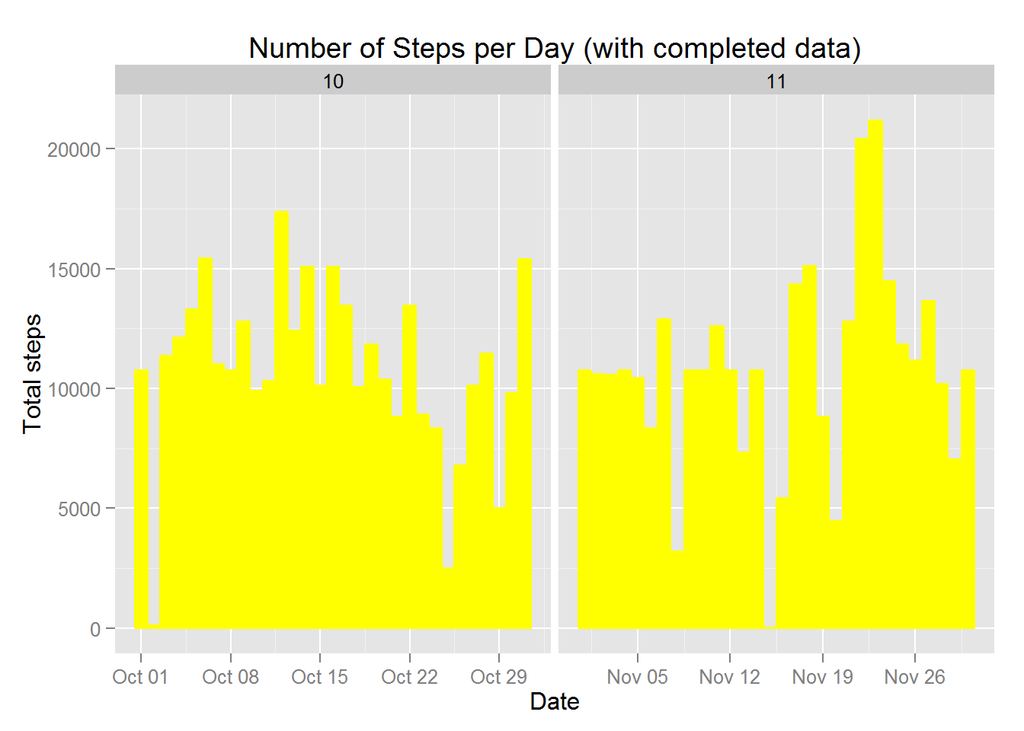

```r
ggplot(updated_Data, aes(date, steps)) + geom_bar(stat = "identity", colour = "yellow", fill = "yellow", width = 1) + facet_grid(. ~ month, scales = "free") + labs(title = "Number of Steps per Day (with completed data)", x = "Date", y = "Total steps")
```

```r
updated_steps_mean   <- mean(updated_Data$steps)
updated_steps_median <- median(updated_Data$steps)
```

# **Are there differences in activity patterns between weekdays and weekends?**

**Create a new factor variable in the dataset with two levels - “weekday” and “weekend” indicating whether a given date is a weekday or weekend day**

```r
updated_Data$weekdays <- factor(format(updated_Data$date, "%A"))
levels(updated_Data$weekdays) <- list(weekday = c("Monday", "Tuesday", "Wednesday", "Thursday", "Friday"),weekend = c("Saturday", "Sunday"))
```

**Make a panel plot containing a time series plot (i.e. type = “l”) of the 5-minute interval (x-axis) and the average number of steps taken, averaged across all weekday days or weekend days (y-axis).**

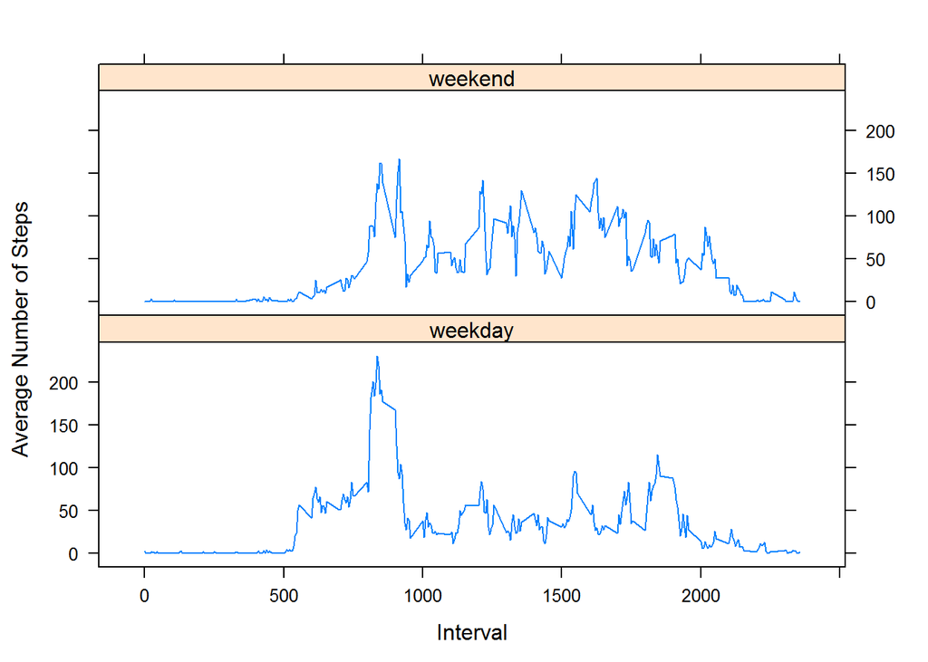

```r
StepsMean <- aggregate(updated_Data$steps, list(interval = as.numeric(as.character(updated_Data$interval)), weekdays = updated_Data$weekdays), FUN = "mean")
names(StepsMean)[3] <- "StepsMean"
library(lattice)
xyplot(StepsMean$StepsMean ~ StepsMean$interval | StepsMean$weekdays,
       layout = c(1, 2), type = "l",
       xlab = "Interval", ylab = "Average Number of Steps")
```